# Análisis de resultados escolares con reducción de la dimensionalidad y agrupamiento

Amilder Stewin Ospina Tobon

Daniel Torres Aguirre

Wilmar Andres Garcia Bedoya

2022-09-06

# Introducción

En este informe, examinaremos una base de datos de universidades de estados unidos, proporcionada por el Departamento de Educación de los Estados Unidos. Nuestro objetivo será realizar un agrupamiento de estas universidades, para luego caracterizar cada grupo, y determinar qué hace que un grupo sea mejor que otro.

# Objetivo

El objetivo de este trabajo es realizar una segmentacion en grupos de universidades en base a las caracteristicas de interes de nuestro analisis. Nuestro interes es el analisis del desempeño academico y como esto podria estar relacionado con el coste de las matriculas, la cantidad de estudiantes que reciben apoyos financieros y las deudas de estos estudiantes, ademas de la cantidad de estudiantes que hay por universidad.

# Carga y limpieza de datos

Inicialmente, cargamos todos los datos. La base de datos contiene 7804 observaciones de 1725 variables.

```
## [1] 7804 1725
```

Podemos examinar las primeras 6 observaciones para hacernos una idea de la estructura de la base de datos, tal como se ve en la tabla 1.

**Tabla 1**  
*Primeras 6 observaciones de la base de datos*

|  | UNITID | OPEID | opeid6 | INSTNM | CITY | STABBR | ZIP | AccredAgency | INSTURL | NPCURL | sch_deg | HCM2 | main | NUMBRANCH | PREDDEG | HIGHDEG | CONTROL | st_fips | region | LOCALE | locale2 | LATITUDE | LONGITUDE | CCBASIC | CCUGPROF | CCSIZSET | HBCU | PBI | ANNHI | … |
| --- | --- | --- | --- | --- | --- | --- | --- | --- | --- | --- | --- | --- | --- | --- | --- | --- | --- | --- | --- | --- | --- | --- | --- | --- | --- | --- | --- | --- | --- | --- |
| 1 | 100654 | 100200 | 1002 | Alabama A &amp; M University | Normal | AL | 35762 | Southern Association of Colleges and Schools Commission on Colleges | www.aamu.edu/ | galileo.aamu.edu/netpricecalculator/npcalc.htm |  | 0 | 1 | 1 | 3 | 4 | 1 | 1 | 5 | 12 |  | 34.7834 | -86.5685 | 18 | 9 | 14 | 1 | 0 | 0 | … |
| 2 | 100663 | 105200 | 1052 | University of Alabama at Birmingham | Birmingham | AL | 35294-0110 | Southern Association of Colleges and Schools Commission on Colleges | www.uab.edu | www.collegeportraits.org/AL/UAB/estimator/agree |  | 0 | 1 | 1 | 3 | 4 | 1 | 1 | 5 | 12 |  | 33.5022 | -86.8092 | 15 | 8 | 15 | 0 | 0 | 0 | … |
| 3 | 100690 | 2503400 | 25034 | Amridge University | Montgomery | AL | 36117-3553 | Southern Association of Colleges and Schools Commission on Colleges | www.amridgeuniversity.edu | tcc.noellevitz.com/(S(miwoihs5stz5cpyifh4nczu0))/Amridge%20University/Freshman-Students |  | 0 | 1 | 1 | 3 | 4 | 2 | 1 | 5 | 12 |  | 32.3626 | -86.174 | 21 | 6 | 6 | 0 | 0 | 0 | … |
| 4 | 100706 | 105500 | 1055 | University of Alabama in Huntsville | Huntsville | AL | 35899 | Southern Association of Colleges and Schools Commission on Colleges | www.uah.edu | finaid.uah.edu/ |  | 0 | 1 | 1 | 3 | 4 | 1 | 1 | 5 | 12 |  | 34.7228 | -86.6384 | 15 | 8 | 12 | 0 | 0 | 0 | … |
| 5 | 100724 | 100500 | 1005 | Alabama State University | Montgomery | AL | 36104-0271 | Southern Association of Colleges and Schools Commission on Colleges | www.alasu.edu/email/index.aspx | www.alasu.edu/cost-aid/forms/calculator/index.aspx/ |  | 0 | 1 | 1 | 3 | 4 | 1 | 1 | 5 | 12 |  | 32.3643 | -86.2957 | 18 | 9 | 13 | 1 | 0 | 0 | … |
| 6 | 100751 | 105100 | 1051 | The University of Alabama | Tuscaloosa | AL | 35487-0166 | Southern Association of Colleges and Schools Commission on Colleges | www.ua.edu/ | oira.ua.edu |  | 0 | 1 | 1 | 3 | 4 | 1 | 1 | 5 | 13 |  | 33.2144 | -87.5458 | 16 | 10 | 16 | 0 | 0 | 0 | … |

Lo que haremos a continuación será quitar las columnas nulas, es decir, aquellas variables para las cuales no hay información. De esta forma, nuestra base de datos se reduce de 1725 a 551 columnas.

```
## [1] 7804  551
```

Seleccionamos variables relevantes para nuestro problema, y las guardamos en un nuevo dataframe que contiene unicamente esas variables.

Las variables seleccionados fueron las siguientes (ver tabla 2)

**Tabla 2**  
*Variables seleccionadas*

| NAME OF DATA ELEMENT | VARIABLE NAME |
| --- | --- |
| 8-digit OPE ID for institution | OPEID |
| Institution name | INSTNM |
| City | CITY |
| State postcode | STABBR |
| ZIP code | ZIP |
| Control of institution | CONTROL |
| Admission rate for all campuses rolled up to the 6-digit OPE ID | ADM_RATE_ALL |
| Average SAT equivalent score of students admitted | SAT_AVG |
| Flag for distance-education-only education | DISTANCEONLY |
| Enrollment of undergraduate degree-seeking students | UGDS |
| Average net price for Title IV institutions (public institutions) | NPT4_PUB |
| Average net price for Title IV institutions (private for-profit and nonprofit institutions) | NPT4_PRIV |
| Net tuition revenue per full-time equivalent student | TUITFTE |
| Completion rate for first-time, full-time students at four-year institutions (150% of expected time to completion/6 years) | C150_4 |
| Percent of all federal undergraduate students receiving a federal student loan | PCTFLOAN |
| The original amount of the loan principal upon entering repayment | DEBT_MDN |

Veamos cuantos nulos hay en cada columna (ver tabla 3)

**Tabla 3**  
*Número de nulos en cada columna*

|  | x |
| --- | --- |
| OPEID | 0 |
| INSTNM | 0 |
| CITY | 0 |
| STABBR | 0 |
| ZIP | 0 |
| CONTROL | 0 |
| DISTANCEONLY | 421 |
| TUITFTE | 442 |
| ADM_RATE_ALL | 5320 |
| C150_4 | 5356 |
| DEBT_MDN | 1163 |
| SAT_AVG | 6384 |
| PCTFLOAN | 741 |
| UGDS | 714 |
| NPT4_PUB | 5881 |
| NPT4_PRIV | 3051 |

Reemplazamos los valores nulos de cada columna por la mediana de los demas valores existentes en esa columna.

De esta manera, el número de nulos en todas las columnas queda en cero, tal como se ve en la tabla 4.

**Tabla 4**  
*Número de nulos en cada columna luego de la limpieza de datos*

|  | x |
| --- | --- |
| CONTROL | 0 |
| DISTANCEONLY | 0 |
| TUITFTE | 0 |
| ADM_RATE_ALL | 0 |
| C150_4 | 0 |
| DEBT_MDN | 0 |
| SAT_AVG | 0 |
| PCTFLOAN | 0 |
| UGDS | 0 |
| NPT4_PUB | 0 |
| NPT4_PRIV | 0 |

# PCA (Análisis de componentes principales)

Para realizar el agrupamiento, únicamente utilizaremos las últimas 11 variables, ya que las primeras 5, tales como el nombre de la institución o su código, no nos resultan útiles para el clustering.

No se trabajó con las variables originales ya que previamente se seleccionaron manualmente las variables mas relevantes para el analisis de nuestro objetivo.

En la siguiente matriz de correlación podemos ver que no hay una correlación fuerte entre ninguna de las variables (ver tabla 5 y figura 1).

**Tabla 5**  
*Matriz de correlación*

|  | CONTROL | DISTANCEONLY | TUITFTE | ADM_RATE_ALL | C150_4 | DEBT_MDN | SAT_AVG | PCTFLOAN | UGDS | NPT4_PUB | NPT4_PRIV |
| --- | --- | --- | --- | --- | --- | --- | --- | --- | --- | --- | --- |
| CONTROL | 1.00 | 0.03 | 0.28 | 0.12 | -0.07 | -0.02 | -0.01 | 0.41 | -0.41 | -0.12 | -0.09 |
| DISTANCEONLY | 0.03 | 1.00 | 0.02 | 0.01 | -0.03 | -0.01 | -0.01 | -0.02 | 0.05 | 0.00 | 0.00 |
| TUITFTE | 0.28 | 0.02 | 1.00 | -0.09 | 0.16 | 0.36 | 0.20 | 0.33 | -0.10 | 0.07 | 0.37 |
| ADM_RATE_ALL | 0.12 | 0.01 | -0.09 | 1.00 | -0.26 | -0.15 | -0.28 | 0.01 | -0.10 | -0.06 | -0.10 |
| C150_4 | -0.07 | -0.03 | 0.16 | -0.26 | 1.00 | 0.23 | 0.53 | -0.05 | 0.11 | 0.11 | 0.18 |
| DEBT_MDN | -0.02 | -0.01 | 0.36 | -0.15 | 0.23 | 1.00 | 0.16 | 0.33 | 0.06 | 0.25 | 0.36 |
| SAT_AVG | -0.01 | -0.01 | 0.20 | -0.28 | 0.53 | 0.16 | 1.00 | -0.11 | 0.17 | 0.07 | 0.15 |
| PCTFLOAN | 0.41 | -0.02 | 0.33 | 0.01 | -0.05 | 0.33 | -0.11 | 1.00 | -0.18 | 0.21 | 0.22 |
| UGDS | -0.41 | 0.05 | -0.10 | -0.10 | 0.11 | 0.06 | 0.17 | -0.18 | 1.00 | 0.17 | 0.07 |
| NPT4_PUB | -0.12 | 0.00 | 0.07 | -0.06 | 0.11 | 0.25 | 0.07 | 0.21 | 0.17 | 1.00 | 0.00 |
| NPT4_PRIV | -0.09 | 0.00 | 0.37 | -0.10 | 0.18 | 0.36 | 0.15 | 0.22 | 0.07 | 0.00 | 1.00 |

**Figura 1**  
*Matriz de correlación*

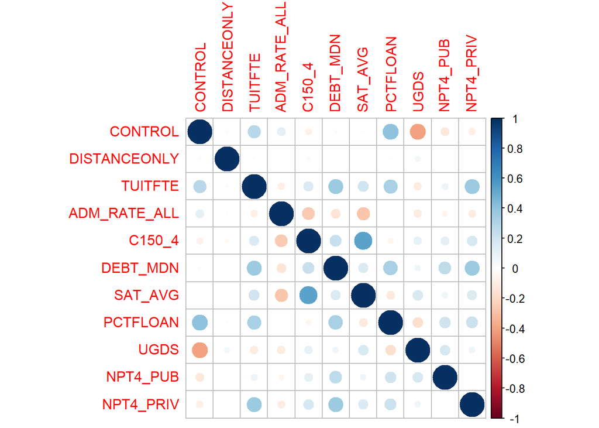

Con las primeras 9 variables de estas 11, se explica un 92.9% de la varianza total.

```
## Importance of components:
##                           PC1    PC2    PC3     PC4     PC5    PC6     PC7
## Standard deviation     1.5349 1.4010 1.1283 1.00884 1.00067 0.9077 0.81402
## Proportion of Variance 0.2142 0.1784 0.1157 0.09252 0.09103 0.0749 0.06024
## Cumulative Proportion  0.2142 0.3926 0.5084 0.60089 0.69192 0.7668 0.82706
##                            PC8     PC9    PC10    PC11
## Standard deviation     0.75752 0.73979 0.66031 0.58756
## Proportion of Variance 0.05217 0.04975 0.03964 0.03138
## Cumulative Proportion  0.87923 0.92898 0.96862 1.00000
```

Sin embargo, las usaremos todas, porque es de nuestro interés analizarlas todas.

# Clustering

## Seleccion del numero de clusters

Para seleccionar el número adecuado de clusters, usaremos el método de Elbow. Veamos la curva generada (figura 2):

**Figura 2**  
*Curva de Elbow*

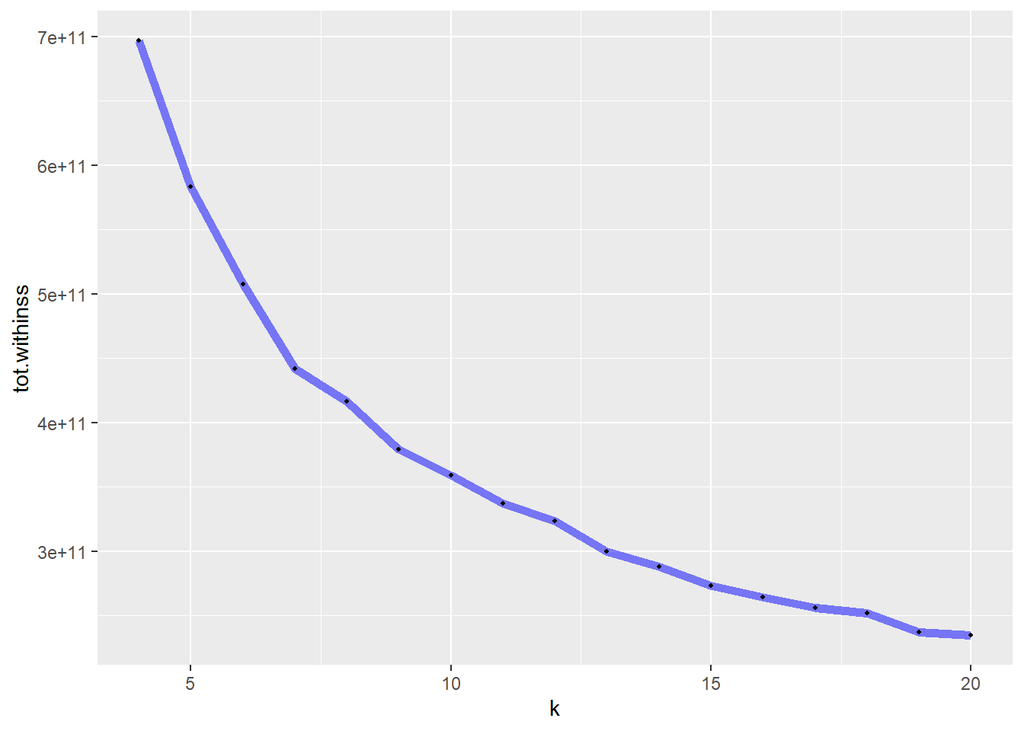

De acuerdo al metodo de Elbow, el número ideal de clusters es 9, ya que se puede apreciar un “codo” en la gráfica cerca a k = 9. A pesar de que en k = 7 hay un codo muy pronunciado, consideramosque entre k = 7 y k = 9 todavia hay una mejora significativa, y a partir de k = 9 las mejoras dejan de ser siginificativas ya que cada vez hay una pendiente menor.

## Agrupamiento con K-means

Para realizar el agrupamiento, utilizaremos k-means con 9 clústers. El resultado del agrupamiento de puede apreciar en la siguiente figura (figura 3)

**Figura 3**  
*Agrupamiento con k-means*

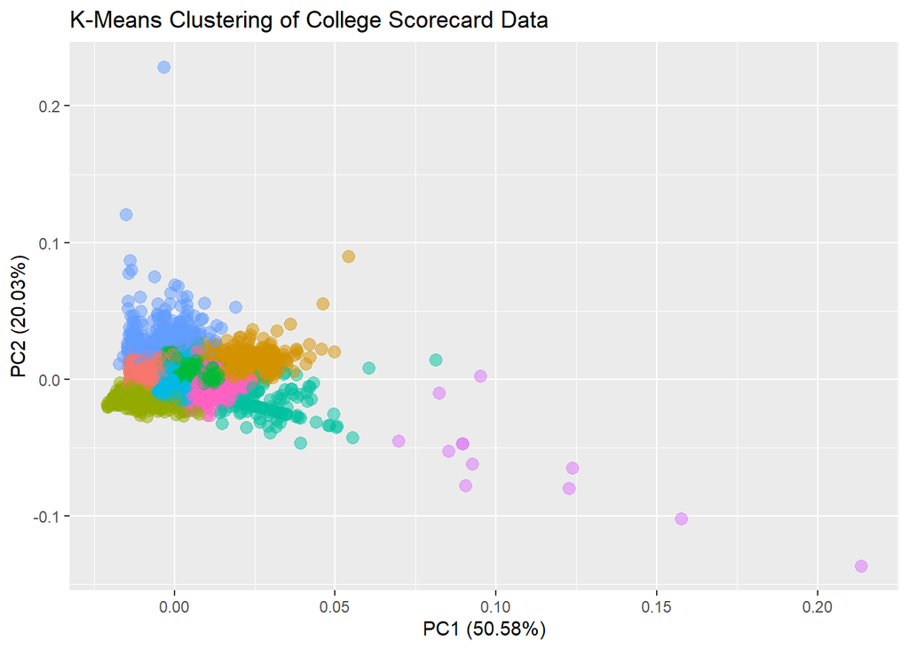

## Caracterización de los clusters

A continuación, revisaremos cada uno de los clusters y examinaremos sus principales características. En el siguiente gráfico (ver figura 4), llamado gráfico de radar, se presentan las medias de los 9 clusters en cada una de las variables, normalizadas entre 0 y 1. Los valores más alejados del centro representan valores más grandes.

**Figura 4**  
*Gráfico de radar de todos los clusters*

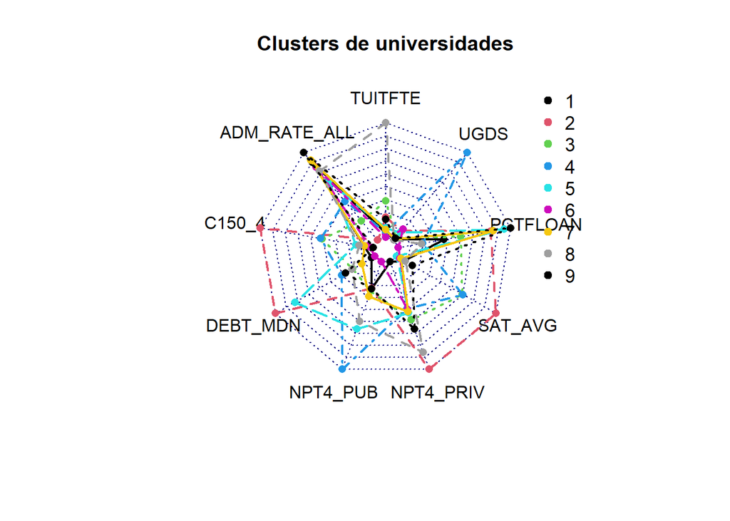